# Prognoza stopy bezrobobocia w Polsce na podstawie danych GUS

Grupa A: Izabela Stobiecka, Anita Księżak, Sandra Sobór, Jakub Bujnowicz

21 kwietnia 2019

Celem poniższego dokumentu jest analiza danych dotyczących stopy bezrobocia w Polsce na podstawie danych GUS i prognoza wysokości stopy na rok 2019.

## Wczytanie danych

Dane zostały wczytane i odpowiednio zmodyfikowane w oddzielnym R skrypcie. Tabela została wyodrębniona ze strony z usunięciem niepotrzebnych znaków, ujednoliceniem separatora dziesiętnego i dodaniem możliwości wyboru wariantu w roku 2002:

w wariancie “a”- dane według wyników z Powszechnego Spisu Rolnego 1996,

w wariancie “b”- dane według wyników z Narodowego Spisu Powszechnego Ludności i Mieszkań oraz Powszechnego Spisu Rolnego 2002

Ustalmy wariant, który weźmiemy pod uwagę:

```r
bezrobocie_typ <- "b"
```

Tabela została również przekształcona do postaci długiej. W ten sposób otrzymaliśmy ramkę danych złożoną z czterech kolumn- Rok, Miesiąc, Wartość i MiesiącInt (miesiąc w postaci liczby całkowitej)

```r
dane <- readRDS(paste0("dane/bezrobocie_",
                       bezrobocie_typ,
                       ".rds"))
names(dane) <- c("Rok", "Miesiac", "Wartosc", "MiesiacInt")
tail(dane)
```

```
##      Rok  Miesiac Wartosc MiesiacInt
## 355 1990 czerwiec     3.1          6
## 356 1990      maj     2.4          5
## 357 1990 kwiecień     1.9          4
## 358 1990   marzec     1.5          3
## 359 1990     luty     0.8          2
## 360 1990  styczeń     0.3          1
```

Wprowadźmy zakres lat, dla kórych przeprowadzimy analizę:

```r
rokStart <- 2012
rokStop <- 2014
```

Ponieważ analizować będziemy dane z okresu 2012 do 2014 przekształćmy odpowienio dane. Pozbądźmy się wartości dla miesięcy,które nie wydarzyły się jeszcze w ostatnim roku.

```r
licznik <- 1
for (i in 1 : 12){
    if(is.na(dane$Wartosc[i])){
        licznik <- licznik + 1
    }
}


if (rokStop == 2019){
    daneStart <- licznik
} else {
    daneStart <- which(dane$Rok==rokStop & dane$Miesiac == "grudzień")
}

daneStop <- which(dane$Rok==rokStart & dane$Miesiac == "styczeń")
```

Zatem początkowe wartości analizowanych danych przyjmują następujące wartości:

```r
dane <- dane[daneStart:daneStop,]
tail(dane)
```

```
##     Rok  Miesiac Wartosc MiesiacInt
## 91 2012 czerwiec    12.3          6
## 92 2012      maj    12.6          5
## 93 2012 kwiecień    12.9          4
## 94 2012   marzec    13.3          3
## 95 2012     luty    13.4          2
## 96 2012  styczeń    13.2          1
```

## Podstawowe wykresy

Ustalmy zmienne start - piewszy parametr w szeregu czasowym oraz frequency - liczbę obserwacji na jednostkę czasu.

```r
s <- 1
f <- 12
```

Zdefiniujmy szereg czasowy opisujący nasze zjawisko i narysujmy dla niego podstawowe wykresy:

```r
bezrobocie <- ts(dane$Wartosc, start = s, frequency = f)
head(bezrobocie)
```

```
##    Jan  Feb  Mar  Apr  May  Jun
## 1 11.4 11.4 11.3 11.5 11.7 11.8
```

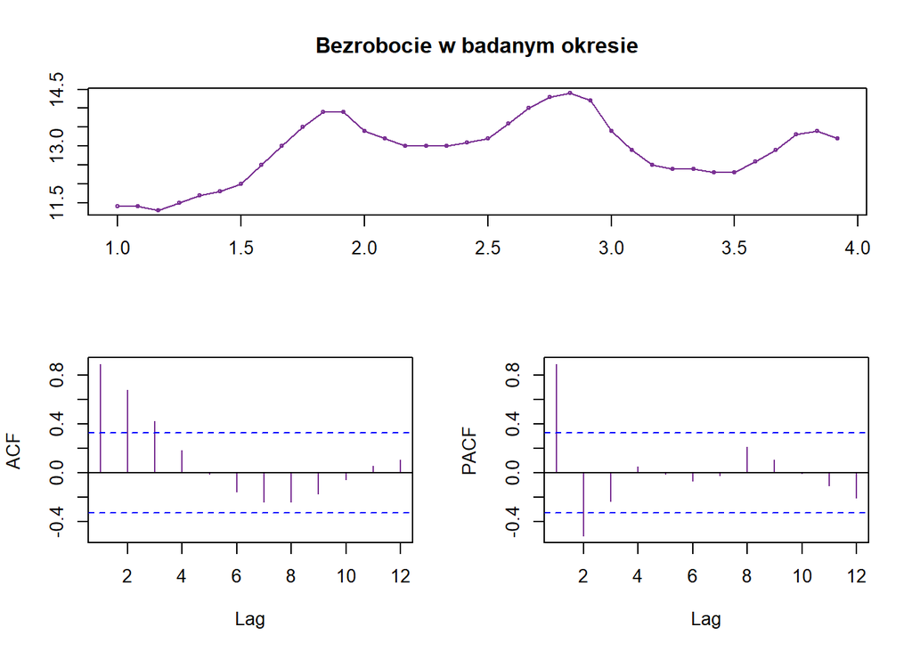

```r
tsdisplay(bezrobocie, main = "Bezrobocie w badanym okresie", col = brewer.pal(n = 4, name = "PRGn")[1])
```

Wprowadźmy parametr q, który odpowiada wartościom istotnie róznym od zera na wykresie ACF oraz parametr p, który odpowiada wartościom istotnie róznym od zera na wykresie PACF Potrkatujmy je chwilowo jako “czarną skrzynkę”. Okażą się one przydatne na dalszym etapie analizy.

```r
q <- 3
p <- 2
```

Narysujmy wykres (za pomocą **STL**) z którego wprost odczytamy oryginalne danr, trend, sezonowość i resztę.

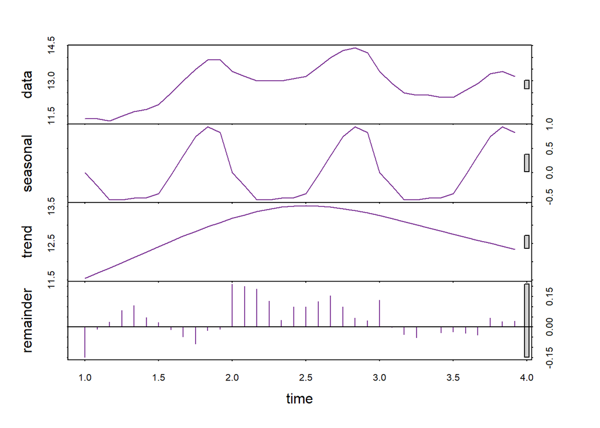

```r
bezrobocie.stl = stl (bezrobocie, s.window = "periodic")
plot(bezrobocie.stl, col = brewer.pal(n = 4, name = "PRGn")[1])
```

Na podstawie powyższych wykresów jesteśmy w stanie odszukać potencjalne trendy i sezonowość. Dodatkowo możemy wyciągnąć wnioski dotyczące stacjonarności danych.

Znając podstawowe własności analizowanego szeregu przejdźmy do dalszej - dokładniejszej analizy.

## AR, MA, ARMA, ARIMA

Aby analiza była dokładniejsza (szereg posiadał cechy słabej stacjonarności) zróżnicujmy eksplorowane dane.

```r
nsc <- diff(bezrobocie)
head(nsc)
```

```
##    Feb  Mar  Apr  May  Jun  Jul
## 1  0.0 -0.1  0.2  0.2  0.1  0.2
```

Narsyujmy wykresy przestawiające zróżnicowane dane.

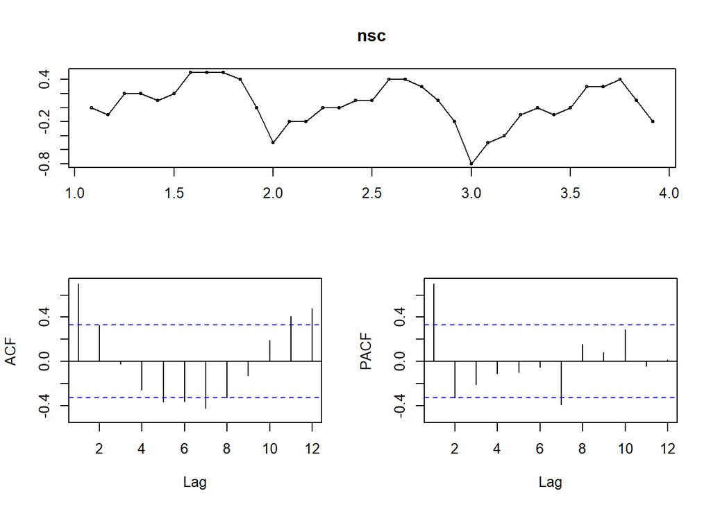

```r
tsdisplay(nsc)
```

Przeanalizujmy dane korzystając z grupy modeli AR, MA, ARMA, ARIMA. Opisy dotyczące modeli pochodzą bezpośrednio ze skryptu dla przedmiotu Szeregi czasowe i prognozowanie w biznesie 2018/19.

Modele **MA** są wyraźnie obserwowalne na wykresach ACF. Wykazują na nich szybą zbieżność do wartości nieistotnie różnych od 0. Wystepowanie q-pierwszych zmiennych na wykresie ACF jako istotnie róznych od zera sugeruje rozwazenie modelu MA(q), zatem na posdtawie wykresu ACF dla niezróżnicowanych danych wnioskujemy, że q=3.

```r
ma <- Arima(nsc, order=c(0,0,q))
summary(ma)
```

```
## Series: nsc
## ARIMA(0,0,3) with non-zero mean
##
## Coefficients:
##          ma1     ma2     ma3    mean
##       0.7917  0.7106  0.3739  0.0326
## s.e.  0.1434  0.1827  0.1652  0.0935
##
## sigma^2 estimated as 0.04426:  log likelihood=6.44
## AIC=-2.87   AICc=-0.8   BIC=4.9
##
## Training set error measures:
##                       ME      RMSE       MAE MPE MAPE    MASE       ACF1
## Training set 0.001711138 0.1979936 0.1422178 NaN  Inf 1.02219 0.08898779
```

```r
ar <- Arima(nsc, order=c(p,0,q))
summary(ar)
```

```
## Series: nsc
## ARIMA(2,0,3) with non-zero mean
##
## Coefficients:
##          ar1      ar2     ma1     ma2     ma3    mean
##       0.7790  -0.5559  0.0776  0.6138  0.2719  0.0394
## s.e.  0.3401   0.2756  0.3521  0.1641  0.1982  0.0796
##
## sigma^2 estimated as 0.04299:  log likelihood=7.88
## AIC=-1.76   AICc=2.39   BIC=9.13
##
## Training set error measures:
##                        ME      RMSE       MAE MPE MAPE     MASE       ACF1
## Training set 0.0006521507 0.1887227 0.1405742 NaN  Inf 1.010377 0.04395146
```

W badaniu procesów **ARMA** wykresy ACF oraz PACF nie wnoszą istotnych informacji. Brak informacji płynącej z wykresów ACF i PACF przy jednoczesnym przekonaniu o stacjonarności jest sygnałem do rozważenia modelu ARMA. Zajmijmy się więc analizą modelu **ARIMA** (ang. Autoregressive integrated moving average - autoregresyjny(**AR**) (AR zintegrowany(**I**) model średniej ruchomej(**MA**)). W celu analizy danych skorzystamy z funkcji wbudowanej w R.

```r
arima <- auto.arima(nsc)
summary(arima)
```

```
## Series: nsc
## ARIMA(1,0,0)(0,1,0)[12] with drift
##
## Coefficients:
##          ar1    drift
##       0.4958  -0.0107
## s.e.  0.1826   0.0030
##
## sigma^2 estimated as 0.008935:  log likelihood=22.52
## AIC=-39.05   AICc=-37.78   BIC=-35.64
##
## Training set error measures:
##                       ME       RMSE        MAE MPE MAPE      MASE
## Training set 0.001370895 0.07322032 0.04714876 NaN  Inf 0.3388817
##                     ACF1
## Training set -0.04521452
```